Litigation DashboardUser Tutorial

Welcome

IDLC · Special Asset Management

# The Litigation Dashboard A complete walkthrough

Everything you need to read, filter and export the bank's litigation portfolio — the summary view, the three case registers (NI, ARA & ARAE), case drill-downs, hearing schedules and CSV exports.

SUMMARY

Portfolio totals by suit & status

NI

Negotiable Instrument Act cases

ARA

Artha Rin Aine cases

ARAE

Artha Rin Aine Execution cases

Navigate with`←``→`arrow keys, the buttons below, or the dots. Press`F`for full screen.

01What the dashboard is for

# One report for the whole litigation portfolio

The dashboard reads the latest litigation snapshot from the analytics database and presents it as an interactive, self-contained web page — no login, no server. It always shows the data as of the **Report Date** printed in the top-right corner.

### 📊Summarise

See total cases, suit value, receivable, overdue and average aging across NI, ARA and ARAE at a glance.

### 🔎Investigate

Drill from a client, to an account, to a single case — with the full case file and hearing history.

### 🎛️Filter

Narrow by branch, customer, account, product, status and upcoming hearing window in real time.

### ⬇️Export

Download exactly what you have filtered to a CSV file for offline work or sharing.

💡

**Self-contained & offline.** The whole dashboard is a single HTML file. You can open it directly in a browser or email it — all the data and interactivity travel inside the file.

02Getting your bearings

## Layout & navigation

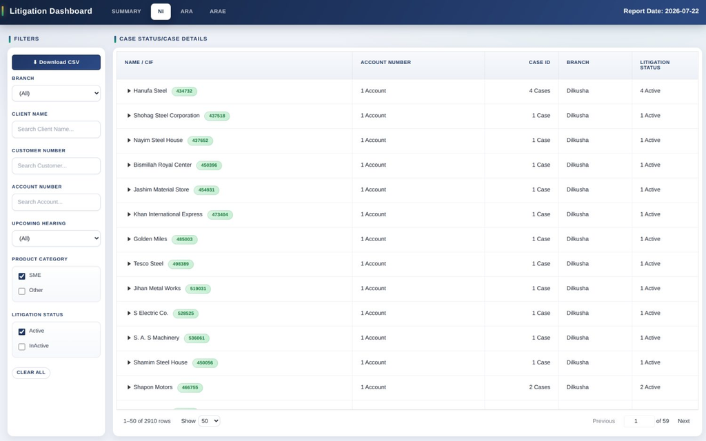

1 2 3 4

Every page shares the same frame: a tab bar on top, a filter rail on the left, and the data on the right.

- 1**Tab bar.** Switch between SUMMARY, NI, ARA and ARAE. The active tab is highlighted in white.
- 2**Report Date.** The "as-of" business date of the data. Everything you see reflects this date.
- 3**Filter rail.** All the controls that narrow the table live here, on the left of every page.
- 4**Data area.** The summary table or the case register, filling the rest of the page.

🧭

Tip: the tab bar and Report Date stay put on all four pages, so you always know where you are and how current the data is.

03The SUMMARY tab

## The portfolio at a glance

The Summary opens on three rows — one for each suit type — with a bold **Total** line beneath. It's the fastest way to gauge exposure before you dive into individual cases.

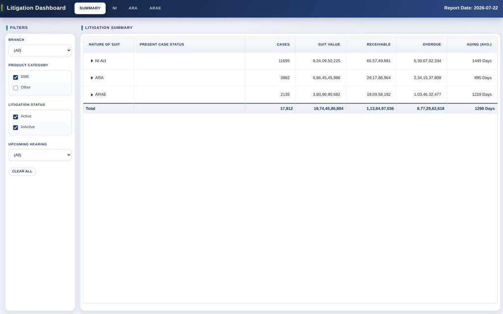

SUMMARY — collapsed to the three suit types with a grand Total footer.

- A**Nature of Suit** — NI Act, ARA and ARAE, each a group you can expand.
- B**Cases** — number of distinct litigation cases in that bucket.
- C**Suit Value** & **Receivable** — the claimed value and the litigation receivable, formatted in the lakh/crore convention.
- D**Overdue** — total overdue amount tied to those cases.
- E**Aging (Avg.)** — the average age of the cases, in days.
- F**Total** row — column totals for whatever is currently filtered in.

🔢

**Totals follow your filters.** Change a branch or status and the Total line recomputes instantly, so it always reflects the slice you're looking at.

04Summary · drill into statuses

## Expand a suit type to see its stages

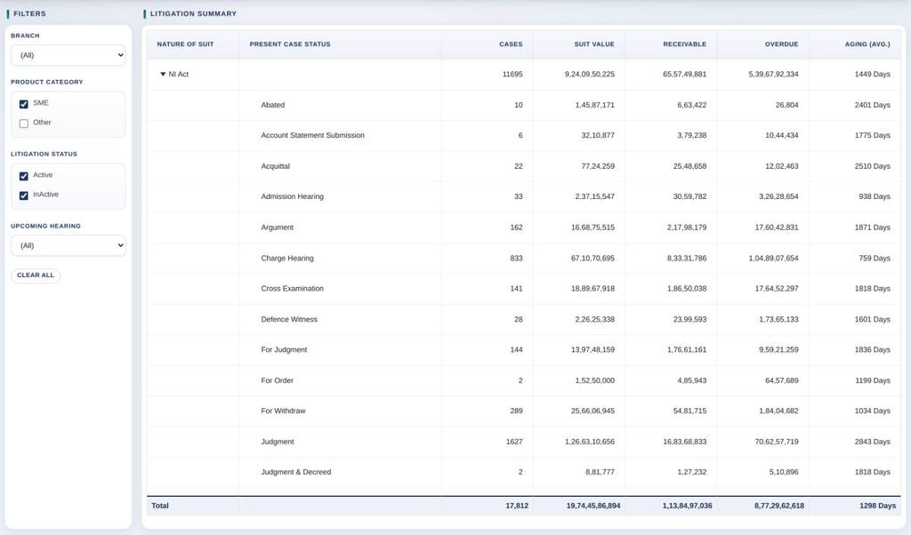

1

📌

Only the suit-type rows expand here — the status rows are the deepest level in Summary. For individual cases, use the NI / ARA / ARAE tabs.

05Summary · filters

## Slice the summary

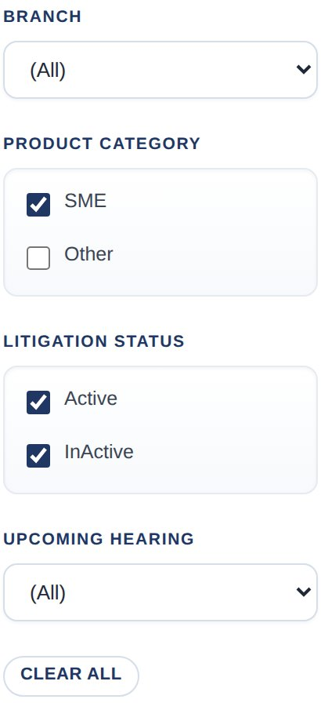

The Summary filter rail.

- 1**Branch** — restrict every total to a single branch.
- 2**Product Category** — SME is ticked by default; add **Other** to include the rest of the book.
- 3**Litigation Status** — **Active** and **InActive** are both on by default here, so totals cover the whole portfolio.
- 4**Upcoming Hearing** — keep only cases whose next hearing falls in a chosen window (see the dedicated slide).
- 5**Clear all** — resets every filter back to its default in one click.

06The case registers

## Three tabs, one identical layout

NI, ARA and ARAE each list the individual cases for one type of suit. They look and behave **exactly the same** — learn one and you know all three.

### NINegotiable Instrument Act

Cheque-dishonour cases under the NI Act. Typically the largest register, driven by the cheque tied to each account.

### ARAArtha Rin Aine

Money-loan-court suits filed to recover the outstanding under the Artha Rin Adalat Ain.

### ARAEARA Execution

Execution cases that enforce a decree already obtained in an Artha Rin suit.

🔁

Because the three tabs are structurally identical, every instruction on the next slides applies equally to NI, ARA and ARAE.

07Reading the case table

## Grouped by client, then account, then case

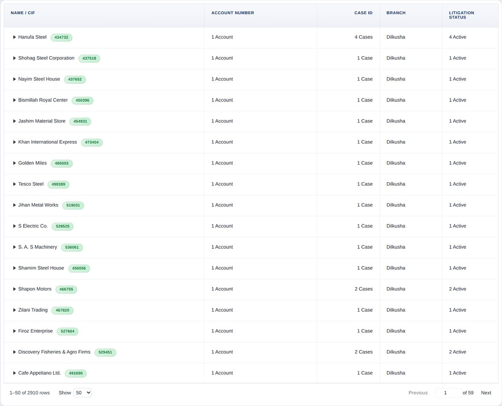

Each top row is one client. The green badge is the customer's **CIF**.

- 1**Name / CIF** — the client name with their CIF number in a green badge, e.g. 434732.
- 2**Account Number** — collapsed to a count (*"1 Account"*, *"3 Accounts"*) until you expand.
- 3**Case ID** — likewise shown as *"4 Cases"* at the group level.
- 4**Branch** and **Litigation Status** — the owning branch and a count of active cases.
- 5**Pagination** — the row count, page-size selector and page jumper sit at the bottom.

08Drilling down

## Client → Account → Case

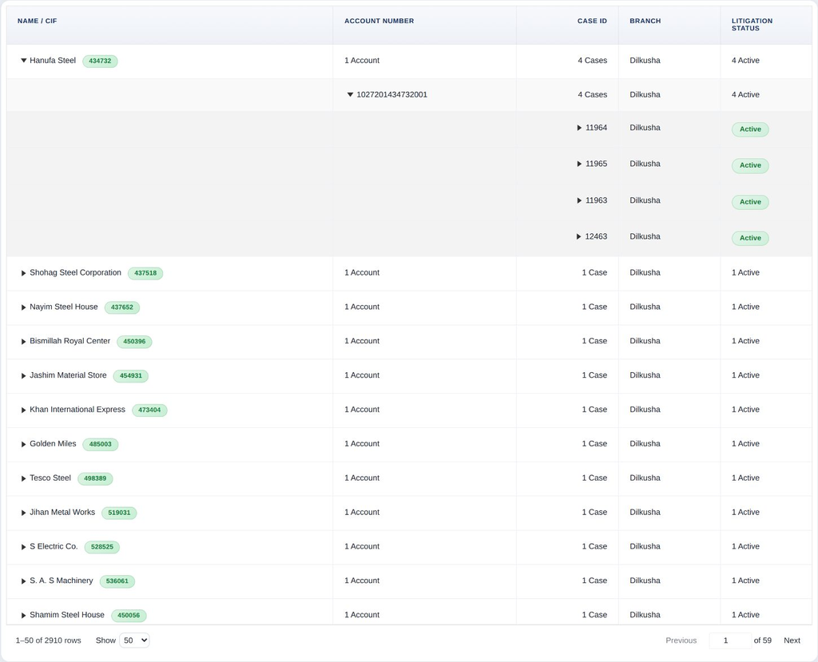

"Hanufa Steel" opened to its account, then to four case IDs — each an Active case ready to open.

Level 1

#### Client

Click a client row to reveal their account(s).

→

Level 2

#### Account

Click an account to reveal its case IDs.

→

Level 3

#### Case

Click a case ID to open its full file.

🖱️

Each ► arrow expands one more level. A client may hold several accounts, and an account several cases — the counts you saw collapsed tell you how many to expect.

09The case file

## Everything about one case

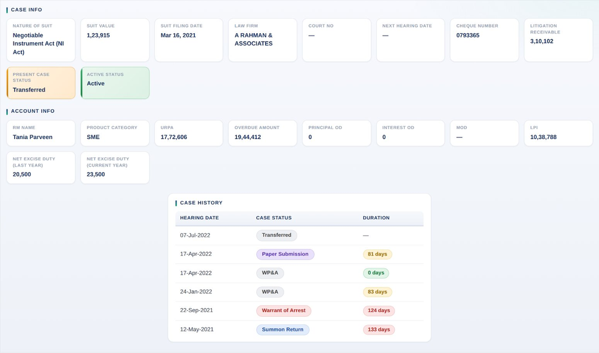

1 2 3 4 5

Expanding a case ID reveals its complete file, built the moment you open it.

- 1**Case Info** — nature of suit, suit value, filing date, law firm, court no, next hearing, cheque number and litigation receivable.
- 2**Present Case Status** — the current stage, highlighted in amber.
- 3**Active Status** — green when the case is Active, red when InActive.
- 4**Account Info** — RM name, product, URPA, overdue, principal/interest OD, MOD, LPI and excise duty.
- 5**Case History** — every past hearing: the date, the status pill, and the days between hearings.

10Reading the colours

## What the pills mean

Colour is used consistently across the whole dashboard, so a glance tells you a case's health and where it stands.

### Case & hearing status

Statuses in the case file and history are tinted by type:

Summon Return Paper Submission Steps Warrant of Arrest Withdrawn / Transferred

Active InActive

### Aging (days between hearings)

In the Case History, the **Duration** pill shows how long a case sat at each stage:

under 30 dayshealthy — moving quickly

30 – 90 dayswatch — some delay

90+ daysslow — long gap between hearings

🎨

The same green / amber / red logic recurs everywhere: green is good and current, amber asks for attention, red flags a problem or a stalled case.

11Filtering the register

## Find exactly the cases you need

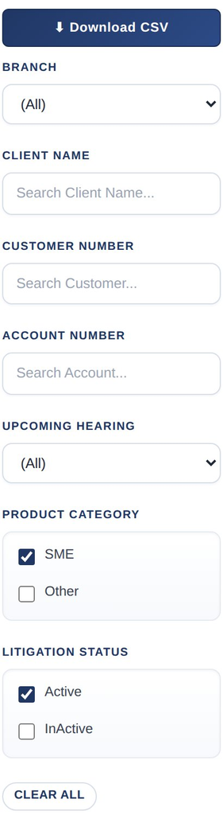

The NI / ARA / ARAE filter rail.

- 1**Branch** — pick a single owning branch.
- 2**Client Name / Customer / Account** — type-ahead search boxes; suggestions narrow as you fill the others.
- 3**Upcoming Hearing** — keep only cases with a hearing in a chosen window.
- 4**Product Category** — SME by default.
- 5**Litigation Status** — Active only by default; tick **InActive** to include closed cases.
- 6**Clear all** — back to the default (Active + SME) view.

🔗

**Filters are linked.** Choosing a branch trims the Customer, Client-name and Account suggestion lists to just what's valid — so you can't search for a combination that doesn't exist.

12Upcoming hearing windows

## Plan around the next hearing

The **Upcoming Hearing** dropdown buckets each case by when its next hearing date falls — invaluable for preparing the week or month ahead.

### 📅Today

Hearing is scheduled for the current date.

### ⏭️Next 5 Working Days

A hearing lands within the next five business days (bank holidays & weekends excluded).

### 🗓️This Month

Next hearing falls within the current calendar month.

### ➡️Next Month

Next hearing falls in the following calendar month.

### ⌛Later

A future hearing beyond next month.

### ⚠️Not Updated / No Date

**Not Updated** = the last hearing date has passed with no new date entered; **No Date** = none recorded.

🧮

"This Month" and "Next Month" are worked out from the real hearing date, so a case can appear in a month bucket even if it's also within the next-5-working-days window.

13Exporting to CSV

## Take the data with you

Every case tab has a **⬇ Download CSV** button at the top of the filter rail. It exports the cases **currently visible after filtering** — not the whole book — with every detail column flattened into one row per case.

Step 1

#### Filter

Set branch, status, hearing window — whatever you need.

→

Step 2

#### Download

Click ⬇ Download CSV.

→

Step 3

#### Open

A file like *litigation_ni.csv* saves, ready for Excel.

### 🧾What's in the file

Client, CIF, account, case ID, branch and status, plus the full case & account detail — nature of suit, court, law firm, cheque, suit value, receivable, next hearing, present status, RM, URPA, overdue, principal/interest OD, MOD, LPI and excise duty.

✅

The export mirrors your filters exactly, so it's the reliable way to hand a precise, reconcilable case list to colleagues or auditors.

14Tips & good habits

## Get more from the dashboard

### 🔄Start from Clear all

When a view looks off, hit **Clear all** to return to the known default (Active + SME) and rebuild your filter from there.

### 📆Check the Report Date

The data is a snapshot. Before you quote a number, glance at the Report Date in the top-right so you're citing the right day.

### 🔍Search beats scrolling

To find one client fast, type into **Client Name** or **Customer** rather than paging through thousands of rows.

### 🗂️Summary first, then drill

Use SUMMARY to spot where exposure sits, then jump to that suit's tab and filter to the same branch/status.

### ⏱️Watch the aging pills

Red duration pills in a case's history point to stages where the case stalled — useful when chasing law firms.

### 📤Filter, then export

The CSV always follows the on-screen filters, so set them precisely before downloading.

15Glossary

## Key terms & abbreviations

| Term | Meaning |
| --- | --- |
| CIF | Customer Information File — the unique customer number (green badge). |
| NI Act | Negotiable Instrument Act — cheque-dishonour litigation. |
| ARA | Artha Rin Aine — money-loan-court recovery suit. |
| ARAE | Artha Rin Aine Execution — enforcing an ARA decree. |
| Suit Value | The value claimed in the suit. |
| Litigation Receivable | Amount recoverable through the litigation. |
| Aging | Age of the case (or days between two hearings) in days. |

| Term | Meaning |
| --- | --- |
| URPA | Unrealised / Regular Principal Amount outstanding on the account. |
| Overdue | Total amount past its due date. |
| Principal OD | Overdue portion of principal. |
| Interest OD | Overdue portion of interest. |
| MOD | Months Overdue. |
| LPI | Late-Payment Interest / penal charge. |
| RM | Relationship Manager owning the account. |

💱

All money is formatted in the **lakh / crore** grouping convention (e.g. *9,24,09,50,225*).

That's the tour

# You're ready to work the portfolio

Summarise on the first tab, drill into any case on NI / ARA / ARAE, filter to the exact slice you need, and export it — all from one file.

### 📊Summarise

Totals by suit & status.

### 🔎Drill

Client → account → case.

### 🎛️Filter

Branch, status, hearings.

### ⬇️Export

Filtered CSV, one click.

Revisit any topic with the dots below, or press`Home`to start over.

1 / 1